[figure not shown]

```python
Image("./img/LogoCTD.png")
```

# Doctorado en Ciencias de Sistemas Digitales

## Seminario de Investigación III

## RESPONSABILIDAD INSTITUCIONAL: en la formación de un alumno de doctorado

### Dr. Roberto Herrera Charles

#### Agosto 2021

[figure not shown]

```python
Image("./img/PoliUnam.png")
```

# CONTENIDO

# RESPONSABILIDAD DE LA INSTITUCIÓN: UNIVERSIDADES e IES

## I. Brindar apoyo a los estudiantes

- Un método estructurado para el alumno doctoral
- Un manual para los estudiantes investigadores de posgrado de la universidad
- Mejorar el idioma, si fuera necesario

## II. Proporcionar recursos para el director de tesis

- El entrenamiento de los directores
- Crédito didáctico para la supervisión doctoral
- El tutor investigador doctoral en la facultad o el departamento

## III. Proporcionar reglamentos adecuados para

- Inscripción y controlar en el progreso de los estudiantes
- Promoción de la maestría al doctorado en la inscripción
- Designación de evaluadores externos

## IV. Proporcionar regulaciones apropiadas

- El doctorado como una serie de proyectos
- Derechos de propiedad intelectual y reconocimiento adecuado de los trabajos de los doctorandos
- El doctorado en una disciplina centrada en la práctica

# V. RESPONSABILIDAD DEL DEPARTAMENTO (Centros de Investigación, Sección de Graduados)

- Nombrar a un tutor investigador de cada departamento
- Mejorar la selección de los estudiantes que ingresan en el departamento
- La selección de los directores
- Elaborar directrices para la conducta eficaz de los directores
- Grupo(s) de apoyo para los estudiantes investigadores

# I. `Brindar apoyo a los estudiantes`

## 1. El éxito de los estudiantes de doctorando

Es también el éxito en las secciones de posgrado de todas las universidad e IES.

- Con su consecuente reflejo en **las calificaciones de investigación de la institución**,
- Se ve afectado en gran medida por el ámbito **(contexto) en el que deben trabajar los estudiantes de doctorado** (Areas de trabajo, de investigación, biblioteca, laboratorio, etc.).

Esto proporciona un reconocimiento institucional de que los estudiantes de doctorado son un componente integral de la universidad para quienes los recursos están disponibles.

1

## 2. No se pide compromisos poco realistas

- Sino simplemente que las universidades asuman la responsabilidad de sus estudiantes investigadores con la misma seriedad con que asumen la responsabilidad de quienes están cursando la licenciatura.
- Desafortunadamente, eso no sucede en muchas universidades.

Aunque en las ultimas decadas esto se ha revertido.

2

**De acuerdo a Stainton**, los cambios en las políticas públicas que están actuando como impulsores del cambio se pueden resumir en cuatro declaraciones (Stainton-Rogers 2004):

1. La necesidad de asegurar que **los graduados de doctorado sean profesionales competentes**.
2. La necesidad de proporcionar **una comunidad de graduados de alta calidad dentro de un medio ambiente**.
3. La necesidad de **adoptar el principio de aprendizaje reflexivo**.
4. La necesidad de **ampliar la participación y establecer un apoyo estudiantil equitativo.**

**Se debe contar con**

- un equipo de supervisión capaz, un entorno de investigación adecuado,
- indicadores de éxito como objetivos de tiempos y tasas de finalización,
- mecanismos efectivos de seguimiento y retroalimentación,

entre otras disposiciones, todos deben estar afinada y en su lugar.

## 3. El director es el responsable

- De brindarle toda la asistencia necesaria en el contenido de la disciplina, en la metodología para la investigación en el desarrollo del tema y además, de inculcarle las pautas profesionales y apoyarlo en el pleno personal.
- Se trata de una gran exigencia y muchos directores solo la cumplen parcialmente.

3

## 4. Todas las instituciones deberían adoptar

### Un procedimiento de iniciación estructurado para los estudiantes investigadores recién inscriptos.

**Después de una conferencia de inducción**

- Un recién ingresado, asistirá semanalmente a una serie de reuniones conducida por un miembro academico sobre la área de ambito de su investigación.
  - Seminarios de laboratorios
  - Seminarios de investigación, etc.

En esas reuniones pueden participar los recién doctorados o una autoridad de la area académica responsable del sistema formal ingreso y seguimiento.

4

#### Las reuniones deberían continuar durante los primeros seis meses.

En un principio deben cubrir temas informativos sobre la universidad:

1. cómo aprovechar al máximo los servicios bibliotecarios o
   - los servicios informáticos académicos;
2. dónde encontrar académicos o estudiantes de investigación relevantes en otros departamentos.

Si somos miembros de universidades, olvidamos lo difícil que es unirse a instituciones tan grandes y lo fácil que es perderse.

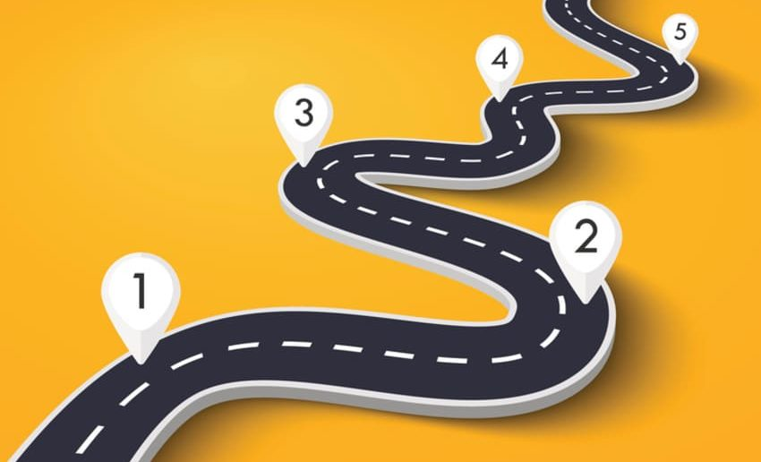

```python
Image("./img/procEstruct2.png")
```

## 5. Un área importante es el entrenamiento

Las reuniones posteriores deberían cubrir temas de proceso tales como

1. La relación entre los estudiantes y sus supervisores,
2. Las expectativas y los temores del papel del estudiante de investigación,
3. La importancia de trabajar con los plazos (deadline) (Phillips, 2001)

En las habilidades profesionales que requiere la investigación.

- Entrenamiento de comunicación
- Metódos de investigación,
- Trabajo en equipo, entre otras.

5

## 6. En la capacidad de comunicación,

Según lo recomendado por los consejos de investigación, las sesiones que fomenten el desarrollo de las habilidades genéricas

- Las habilidades para redactar y
- Disertar ante el público y
- Eficiencia personal
- Las capacidades habilidades computacionales,
  - dado que en el programas doctoral en cada uno de esos dominios son en ocasiones ostensiblemente inadecuados.

Además de ayudar al estudiante en ese momento, estas habilidades aumentarán la probalidad de ser contratado al momento graduarse el estudiante.

6

# 7. Cada departamento o laboratorio

- Ha de contar con un espacio y recursos suficientes como para proporcionar una sala con escritorios destinados a los estudiantes investigadores.
- La sala también puede funcionar como lugar de encuentro para graduados de otras facultades.

7

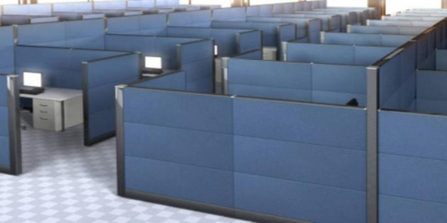

```python
Image("./img/cubicu.png")
```

[figure not shown]

```python
Image("./img/Lab.png")
```

## 8. La institución se asegurará de que

- Los estudiantes investigadores de doctorado tengan por:
  - ejemplo, un espacio para el laboratorio y los dispositivos necesario para su investigación,
  - el acceso a un técnico y los servicios mas generales que se ofrecen
    - en computación y
    - a una biblioteca adecuada.  
      [Biblioteca del CITEDI](https://biblioteca.citedi.mx/portal/)  
      [Biblioteca digital del IPN](https://www.bibliotecadigital.ipn.mx/login)

#### 8

[figure not shown]

```python
Image("./img/Biblioteca.png")
```

# 9.- Las universidades buscarán recursos económicos para

- Uso exclusivo de los estudiantes.
- Así como dinero para conferencias,
- Fotocopias y gastos de viaje.

#### 9

[figure not shown]

```python
Image("./img/fd.png")
```

## 10. Es preciso contar con un manual para estudiantes de grado de investigación universitaria

Es una parte importante para comunicar la naturaleza de los estudios e investigación de posgrado y el marco universitario en donde se lleva a cabo. Este debe actualizarse periódicamente.

**La información clave incluiría:**

- Una descripción de la estructura de la universidad,
- Regulaciones para admisión o registro, actualización,
  - Tarifas, exámenes, premios y `un código de práctica para directores (supervisores) y estudiantes` de investigación.

#### 10

[figure not shown]

```python
Image("./img/manual.png")
```

## 11. `Código de práctica para directores y estudiantes`

El código debe explicitar lo que esperan legítimamente

- **los estudiantes de los directores** (por ejemplo, destreza en la materia y en el tema, frecuencia y duración óptimas de las reuniones tutoriales, rápidas y constructivas respuestas al trabajo escrito presentado) y, a la vez
- **lo que espera el director del estudiante** (trabajar con conciencia e independencia, llevar un registro del trabajo experimental del laboratorio, presentar trabajos escritos en el tiempo acordado).

#### 11

## 12.- Cuando se acepta a estudiantes extranjeros

Para cursar el programa de doctorado, es responsabilidad de la universidad y no del director mejorar su dominio del idioma.

- La universidad debería prever esto ofreciendo clases a todos los que las necesiten.
  - Los hablantes nativos del idioma oficial a veces también pueden beneficiarse de estas clases.

#### 12

[figure not shown]

```python
Image("./img/idioma1.png")
```

[figure not shown]

```python
Image("./img/idioma2.png")
```

## 13.- Apenas comienza el período de inscripción,

- Es preciso comunicarles la necesidad de dominar el idioma y
- Cual es el nivel requerido para la redacción de la tesis y las publicaciones internacionales B2 + 4 habiidades.

#### 13

[figure not shown]

```python
Image("./img/Cenlex.png")
```

# II. `Proporcionar recursos para la dirección`

## 1. El entrenamiento es imprescindible

- Para que los académicos cumplan con eficacia la función de directores.
  - Nuestra opinión se deriva del hecho de haber participado, durante años, en **grupos de discusión** a los que concurrían directores de distintas universidades.
- El trabajo de la dirección de tesis es un aspecto del trabajo académico pocas veces discutido.

#### 14

## 2. Corresponde a la universidad o IES

- La asignación de recursos para aumentar el número de esos **grupos de discusion**,
- Pues resultan indispensables tanto para los directores menos experimentados como para los más expertos.

#### 15

## 3.- Los directores de tesis

Tendrán la oportunidad de analizar lo que cada uno de ellos considera necesario para una buena supervisión.

#### 16

[figure not shown]

```python
Image("./img/grupo.png")
```

## 4.- Un importante prerrequisito

- Para mejorar **la competencia en la supervisión** es necesario asignar créditos didácticos/docente a la supervisión doctoral.
- Se espera que los directores acepten a los doctorandos, además de cumplir con sus otros deberes.

#### 17

## Es necesario establecer y apoyar

- En todas las secciones universitarias, en el papel desempeñado por el tutor (investigador) doctoral de la facultad o del departamento
  - para asegurar el buen funcionamiento del sistema de doctorado.

#### 18

## 5. Igualdad y equidad

- Las universidades deben tener una política que impulse a sus facultades a pensar con más amplitud cuando
  - consideran la inscripción de aspirantes que carecen de las habilitaciones comunes para ingresar una investigación de grado.
- Ello incluirá el control étnico.

Se necesitan políticas que fomenten el desarrollo de:

- la igualdad, la integración y la afiliación entre todos los estudiantes,
- así como procedimientos que brinden apoyo a las víctimas y denuncias del acoso en todas sus formas.

#### 19

# III. Proporcionar regulaciones apropiadas

## 1. Trayectoria del alumno de doctorado

- La universidad debe establecer reglas que aseguren el control eficaz del progreso de los estudiantes de doctorado.
- Es fundamental contar con informes anuales sobre cada uno de los graduados examinados por el departamento.

Que han de ser revisados por un comite (panel) asesor de tesis que puede consistir por ejemplo, el jefe de departamento, el tutor de investigación y los directores de tesis

#### 20

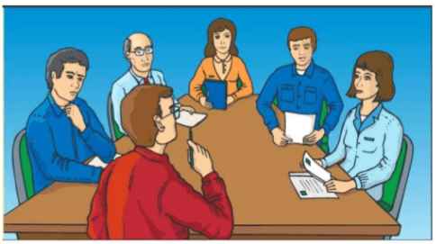

```python
Image("./img/examen.png")
```

## 2. Alumnos que continuan de Maestria a Doctorado

- Es indispensable contar con normas formales para determinar si es posible
  - promover al estudiante de la maestría al doctorado y cuando hacerlo.
- Las pautas o acuerdos departamentales que indican:
  - cómo se interpretarán los procedimientos(Maestria a Doctorado) pueden entonces ser explícitamente a los estudiantes en un momento de su primer período de registro o inscripción. #### 21

## 3.- Criterios de Graduación

- Los examinadores representan el grupo de pares académicos al cual los estudiantes desean pertenecer.
- La tesis demuestra que el aspirante al doctorado ha contribuido a la investigación con un trabajo de calidad y merece, por tanto, obtener el grado de doctor. #### 22

## Designación de evaluadores externos

- El sistema de algunas Universidades o IES procuran igualar las pautas de otras universidades y exige la designación de por lo menos un examinador externo perteneciente a otra institución.

#### 23

# IV. `Proporcionar un foro para la revisión del doctorado`

Es proporcionar un foro en el que se puedan establecer políticas y prácticas para el mantenimiento y mejora de la experiencia educativa de todos los estudiantes de doctorado en la universidad

- Foro: revisión del doctorado
- Un foro académico representativo brinda la oportunidad de debatir dichos cambios.
- Aquí examinamos tres importantes cuestiones que figuran aun en los programas de muchas universidades.

#### 24

## 1.- Tres importantes questiones.

1. El doctorado como una serie de proyectos
2. Derechos de propiedad y reconocimiento adecuado de los alumnos.
3. El doctorado como una disciplina centrada en la práctica. #### 25

## 2. El doctorado como una serie de proyectos

Al principio, sería mucho más delicado exigir a los estudiantes que demuestren **su rango de habilidades profesionales a través de una serie de proyectos más pequeños**, y más realista que un proyecto grande y único.

- De hecho, este abordaje permitirá solicitar la admisión al “doctorado por trabajos publicados”, una vía ofrecida por muchas universidades, pero
- En la actualidad sólo es posible a los doctorandos con dedicación exclusiva y sin el beneficio de la supervisión.

#### 26

## Ventajas del doctorado por serie de proyectos

- Una serie de proyectos puede ser una ventajosa alternativa del doctorado obtenido a partir de una investigación.

**Por lo tanto**,

- el doctorado debe otorgarse sobre la base de, digamos,
  - cuatro proyectos vinculados conceptualmente,
  - cada uno de los cuales se lleva a cabo según los estándares de los artículos publicables en revistas académicas arbitradas.

#### 27

### 3. El doctorado en una disciplina basada en la práctica

En disciplinas basadas en la práctica:

- como el arte, la música o
- el diseño y la tecnología,
  - existe un debate en curso sobre la forma de un doctorado.

Dado que el avance del conocimiento en estas disciplinas es en gran parte por medio:

- de la práctica profesional y artística,
- un artefacto original y creativo

  puede incluirse adecuadamente como parte de una presentación de doctorado.

Esto ahora se acepta en la mayoría de las universidades e IES.

## 3. Derechos de Propiedad Intelectual (PI)

Al saber de que el conocimiento es el recurso clave en la sociedad moderna, las cuestiones relacionadas a la propiedad de dicho conocimiento son cada vez más polémicas.

- Según la ley, todos los autores (incluso los doctorandos) están habilitados para **percibir los beneficios que son producto de los derechos de propiedad intelectual** de su obra escrita y publicada; y
- También para ejercer los **“derechos morales”** de reconocimiento y de integridad.

El argumento es que la provisión de recursos para la realización de la investigación da derecho a la universidad a ser propietaria de los productos, al igual que los productos de los empleados.

#### 28

## 4.- Derechos de Propiedad Intelectual

Hay grandes variaciones entre las culturas de diferentes disciplinas sobre PI

- Los conflictos surgen cuando los estudiantes desconocen las convenciones apropiadas y los directores presionan, arbitrariamente, para que sus nombres se incluyan entre los autores.
- Cuando los directores presionan a los alumnos para que aparescan colaboradores sin ninguna aportación, etc.

#### 29

# 4.- Reglas sobre los Derechos de PI

Por ejemplo, en las directrices de la universidad de Honk Kong se postula lo siguiente:

- Todos aquellos que han contribuido auténtica y significativamente al trabajo (y sólo aquellos) figuran como sus autores.
- El orden de aparición debe corresponderse con la contribución al trabajo.
- No se incluirán los nombres de los autores a menos que demuestren su competencia y conocimientos en el tema del trabajo

#### 30

[figure not shown]

```python
Image("./img/patente2.png")
```

[figure not shown]

```python
Image("./img/patente1.png")
```

# V. `RESPONSABILIDADES DEL DEPARTAMENTO (Centros de Investigación, Sección de Graduados)`

## 1.- Responsabilidad de Departamentos de Investigación

**Los departamentos constituyen un factor clave en la educación doctoral fecunda:**

1. ¿Cómo ayudan los departamentos a investigar a los estudiantes de posgrado de un modo fructífero?
2. ¿De qué estrategias se valen para contrarrestar el aislamiento y permitir a los estudiantes que aprendan de otras personas que no sean sus directores?
3. ¿Se crean grupos de autoayuda para enseñar a los estudiantes a aprender los unos de los otros?
4. ¿se tomaron medidas para que los estudiantes desarrollen sus concepciones de lo que significa una excelente investigación en su disciplina y de su papel como investigadores?

#### 31

### El tutor de investigación departamental

Cada departamento debe asegurarse de recibir recursos para establecer un papel de tutor de investigación.

- Los tutores deben tener esta responsabilidad administrativa reconocidos formalmente como parte de su carga de trabajo general.

## 2.- Responsabilidad de los departamentos de Posgrado en las seleccion de alumnos

#### 32

## 3.- La selección de los directores

La selección de los directores

- Incumbe al departamento establecer criterios adecuados para la selección de los directores de tesis.

**Los factores implicados:**

- 1ro. Su experiencia en investigación anterior (cvu) y el presente nivel de actividades de investigación en su campo.
- 2do. Su experiencia de supervisión pasada y grado actual de compromiso con la supervisión de estudiantes de posgrado.

#### 33

## 4. Elaborar directrices para la conducta eficaz de los directores

Corresponde al departamento proporcionar directrices para satisfacer las espectativas del programa doctoral. Y abarca las siguientes:

- El maximo tiempo que puede llevarles revisar un escrito presentado por el alumno: propuesta de tesis, avance y escrito final de la tesis.
- Informar al estudiante sobres los reglamentos universitarios y posgrador a los que el estudiante ha de cumplir durante su formación doctoral.
- Sugerir al estudiante de doctorado y al director de tesis la convencia de hacer acuerdos formales: Lo que esperan los directores de los alumnos, la necesidad de educar al director, codireciones entre otras.
- Proporcionar desde el inicio informacion del progreso del estudiante tanto satisfactorios como los que lo son satisfactorios.
- Aconsejarle en cuentiones relativas a la ética, ponerlo en contacto con diversas personas e ideas dentor de la comunidad academica.

#### 34

# 5.- Grupos de apoyo para los estudiantes investigadores

El aislamiento social es un factor importante que contribuye a la insatisfacción, el abandono y la entrega tardía del trabajo de los estudiantes de investigación.

- A los estudiantes de doctorado se les debe recordar constantemente que no estar trabajando de forma aislada y
- que hay personas que están interesadas en su trabajo y su progreso.
- Incumbe al departamento establecer criterios adecuados para la selección de los directores de tesis.

#### 35

### Auto evaluación sobre progreso de estudiante de investigación

Con la intención de veas tus progresos para la obtención del grado de Doctorado,  
Da tu opinión en cada una de las siguientes declaraciones.  
Elige a cada una de las preguntas, indicando una solo opción:

| Clave | Quiere decir |
| --- | --- |
| TA | Totalmente de Acuerdo |
| A | de Acuerdo |
| I | Indeciso |
| D | en Desacuerdo |
| TS | Totalmente en desacuerdo |

D1. El departamento/Facultad/Centro suministra los recursos físicos y financieros adecuados para mi investigación (p. ej. Laboratorios u otros espacios físicos, equipamiento, acceso a bibliotecas, bases de datos)

| TA () | A () | I () | D () | TS () |
| --- | --- | --- | --- | --- |

D2. El departamento da oportunidades para que los estudiantes de investigación se reúnan para recibir apoyo de uno a otros y de lo cual tome yo ventajas de esto.

| TA () | A () | I () | D () | TS () |
| --- | --- | --- | --- | --- |

D3. El departamento procura un programa de seminarios estimulante para estudiantes de doctorado en el cual yo participe y contribuya.

| TA () | A () | I () | D () | TS () |
| --- | --- | --- | --- | --- |

D4. El departamento da oportunidades para el buen contacto profesional con el personal (staff) académico al cual me he sumado o integrado.

| TA () | A () | I () | D () | TS () |
| --- | --- | --- | --- | --- |

D5. El departamento brinda oportunidades de contacto sociales con el personal académico y tengo ventaja de ello.

| TA () | A () | I () | D () | TS () |
| --- | --- | --- | --- | --- |

D6. El departamento impulsa y soporta la participación a conferencias y otras reuniones académicas en las cuales he participado o voy participar.

| TA () | A () | I () | D () | TS () |
| --- | --- | --- | --- | --- |

D7. El departamento organiza reuniones, en las cuales yo haya participado, para discutir la naturaleza de proceso doctoral y las normas Institucionales (IPN) relevantes que se aplican a mi trabajo de investigación.

| TA () | A () | I () | D () | TS () |
| --- | --- | --- | --- | --- |

D8. Sobre todo, estoy satisfecho con el apoyo que recibo de mi departamento.

| TA () | A () | I () | D () | TS () |
| --- | --- | --- | --- | --- |

# Conclusiones

1. Asegurar que la Institución cumpla las resposabilidades al aceptar alumnos de doctorado en sus programas.
2. Suministras apoyos a los alumnos de doctorado mediante a procedimiento bien estructurados para: iniciación, recursos para laboratorios, proyectos de investigación, ensenanza del ideomas entre otros.
3. Suministrar rescursos para el entrenamiento de directores.
4. Proporcionar reglamentos para la formación doctoral así como foros donde se examine regularmente los avance del alumno de doctorado.
5. En lo que refiere a los departamentos, instituir la función de tutor de alumnos de doctorado para mejorar y medir el funcionamiento de la formación doctoral.
6. Revisar regularmente los métodos de selección y los criterios de admisión de estudiantes.
7. Promover los grupos cooperativos y las reuniones entre estudiantes. #### 36

## Referencias y Bibliografia

1. Phillips, Estelle y Pugh, Derek. Cómo obtener un doctorado. Manual para estudiantes y tutores, Ed. Gedisa, Barcelona, 2003.
2. Wason, P. C. 1968. Reasoning about a rule. Quarterly Journal of Experimental Psychology, 20, pp. 273-81.
3. Wason, P. C. 1974. Notes on the supervision of PhDs. Bulletin of the British Psychological Society, 27, pp. 25-9.
4. Phillips, Estelle y Pugh, Derek. HOW TO GET A PhD. A Handbook for Students and their Supervisors, Ed. Open Univerity Press, USA, 2005.
5. Stainton-Rogers, W. (2004) Policy shifts in PGRS supervision and training. Internal memorandum, Open University, Milton Keynes.